# Part I - (Dataset Exploration Title)

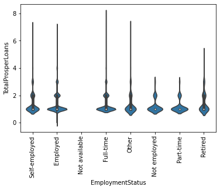

```python
# what is the average properscore per employmentStatus?
# the above question can be answered by understand the plot and we shall see this
color_favorite = sb.color_palette()[0]
sb.violinplot(data = df1 , x = "EmploymentStatus", y = "TotalProsperLoans",color=color_favorite)
plt.xticks(rotation = 90);
```

Hmmm there seems to be alot of outliers across these two variables.

```python
df1.groupby("EmploymentStatus")["TotalProsperLoans"].mean().sort_values(ascending = False)
```

```
EmploymentStatus
Retired          1.446640
Employed         1.441869
Self-employed    1.436923
Other            1.393536
Full-time        1.387018
Not employed     1.226562
Part-time        1.215054
Not available         NaN
Name: TotalProsperLoans, dtype: float64
```

Retired people tends to take more loans than other employment status, this could be that as they retire , thend to take more loans to offset their bills

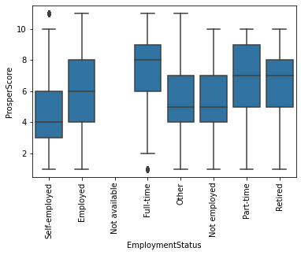

```python
# lets see if the EmploymentStatus relates to the ProsperScore
color_favorite = sb.color_palette()[0]
sb.boxplot(data = df1 , x = "EmploymentStatus", y = "ProsperScore",color=color_favorite)
plt.xticks(rotation = 90);
```

From the plot above i think it is safe to say that the `self employed` persons have the lost median. and the full time would actually have a chance of getting future loan since they pay up their loans faster, and this would indicate that they would have a high prosper score.

```python
new_df.groupby("EmploymentStatus")["ProsperScore"].mean().sort_values(ascending = False)
```

```
EmploymentStatus
Full-time        6.423979
Employed         6.264422
Part-time        6.065041
Retired          5.971154
Other            5.282000
Not employed     4.939655
Self-employed    4.744949
Name: ProsperScore, dtype: float64
```

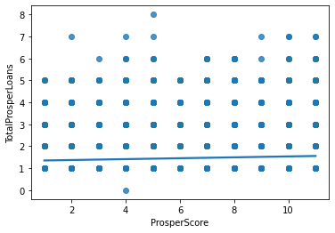

```python
sb.regplot(data = df , x = "ProsperScore", y = "TotalProsperLoans");
```

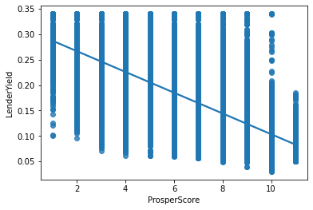

```python
sb.regplot(data = df1 , x = "ProsperScore", y = "LenderYield");
```

There is negative relationship between ProsperScore and LenderYield.

```python
df.groupby("EmploymentStatus")["ProsperRating (numeric)"] .mean()
```

```
EmploymentStatus
Employed         4.142639
Full-time        4.087423
Not available         NaN
Not employed     2.713405
Other            3.599842
Part-time        3.753906
Retired          3.708447
Self-employed    3.639489
Name: ProsperRating (numeric), dtype: float64
```

Employed people have more Propersrating score than Parttime and Retired.

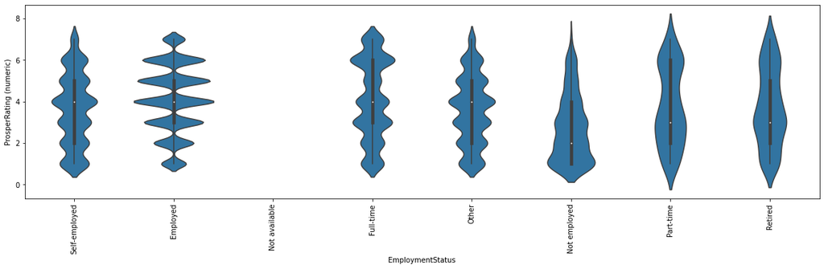

```python
# qualitative vs quantitaive -- categorical vs numwerical
plt.figure(figsize= [20, 5])
sb.violinplot(data = df1 , x ="EmploymentStatus", y =  "ProsperRating (numeric)", color = color_fav)
plt.xticks(rotation = 90);
```

people that are employed tends to have more proper rating score than other employment status-- maybe eince they are employed they proobably get to pay their loan ontime hence the reason for higher average prosper rating

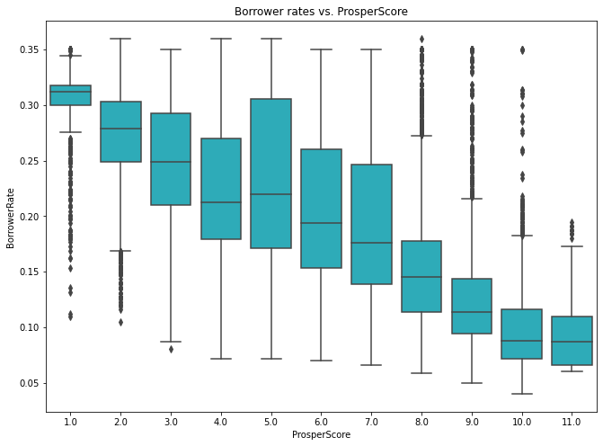

```python
plt.figure(figsize=[11, 8]);
base_color = sb.color_palette()[9];
sb.boxplot(data = df1, x = 'ProsperScore', y = 'BorrowerRate', color = base_color);
plt.title('Borrower rates vs. ProsperScore');
```

Above we can see that there exist a relationship between prosper score and borrower rate, with a lot of outliers towards the right from 8.0 and to the left 1st quartile range from 3.0

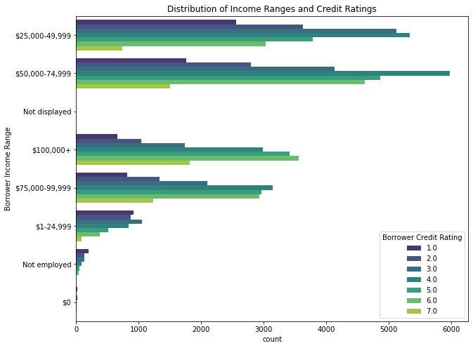

```python
# lets see a clustered bar chart clustered bar chart
plt.figure(figsize = [10,8])

ax = sb.countplot(data = df1, y = 'IncomeRange', hue = 'ProsperRating (numeric)',
                   palette = 'viridis')

ax.legend(title = 'Borrower Credit Rating')
plt.title('Distribution of Income Ranges and Credit Ratings')
plt.ylabel('Borrower Income Range');
```

The above plot, shows the trend of higher and lower incomes and how higher incomes correlate with a higher credit rating qualifying the borrower for better interest rates and rating.

## Multivariate Exploration

> Create plots of three or more variables to investigate your data even further. Make sure that your investigations are justified, and follow from your work in the previous sections.

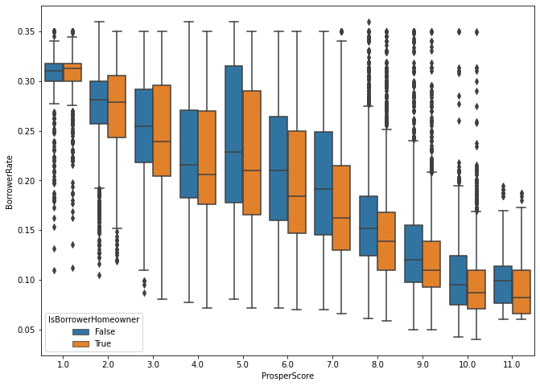

```python
# the Term vs BorrowerRate vs IsBorrowerHomeOwner
plt.figure(figsize=[11, 8]);
sb.boxplot(data = df1, x = 'ProsperScore', y = 'BorrowerRate', hue = 'IsBorrowerHomeowner');
# plt.labels
# plt.title('Year borrower\'s rate vs. ProsperScore vs. isHomeOwner');
```

it is seen that home owners seem to have lower rates than people who don't have home. this is a critical question that can be further analyzed, while to the left of 5.0 home owners either have lower or equal rate that can be seen at 1.0, something is definitely going on in this dataset.

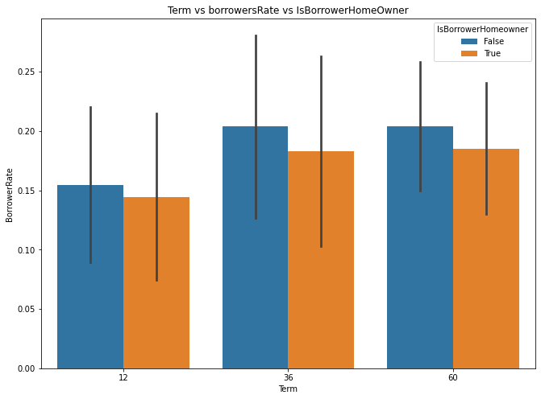

```python
plt.figure(figsize=[11, 8]);
sb.barplot(data = df1, x = 'Term', y = 'BorrowerRate', hue = 'IsBorrowerHomeowner', ci = 'sd');
plt.title('Term vs borrowersRate vs IsBorrowerHomeOwner')
```

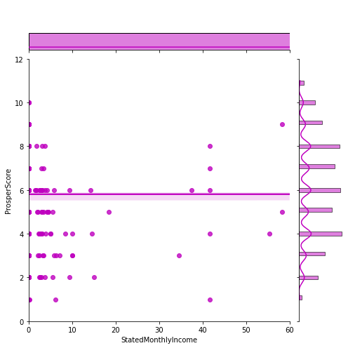

```python
g = sb.jointplot(x="StatedMonthlyIncome", y="ProsperScore", data=df1,
                  kind="reg", truncate=False,
                  xlim=(0, 60), ylim=(0, 12),
                  color="m", height=7)
```

So it appears that StatedMonthlyIncome doesn't really have a relationship with prosper score rating, the question remains why?

### Talk about some of the relationships you observed in this part of the investigation. Were there features that strengthened each other in terms of looking at your feature(s) of interest?

There are alot of relationships in this dataset, to be honest this is just a smudge of what can actually be done in this dataset, although i observed alot of relationship between status of individuals and their borrowerrate and ProsperScores, not withstanding some full time persons having low score probably because of defaulting

### Were there any interesting or surprising interactions between features?

there were a lot of superising interactions especially when the data proved me wrong, thinking that people who have a source of income would have by far better ratings and rate, but to my surprise in some plots the reverse was the case.

## Conclusions

I achieved this by performing multivariate , Bivariate , Multivariate analysis on the Dataset.

> Remove all Tips mentioned above, before you convert this notebook to PDF/HTML

> At the end of your report, make sure that you export the notebook as an html file from the `File > Download as... > HTML or PDF` menu. Make sure you keep track of where the exported file goes, so you can put it in the same folder as this notebook for project submission. Also, make sure you remove all of the quote-formatted guide notes like this one before you finish your report!